# Risk Factor Analysis

## Outcome Variable

**Outcome Variable:** stunted

## Predictor Variables

**Intervention Variable:** exclfeed6

**Adjustment Set:**

- arm
- sex
- brthmon
- W_mage
- meducyrs
- feducyrs
- hhwealth_quart
- hfoodsec
- W_mhtcm
- W_mwtkg
- W_mbmi
- vagbrth
- W_gagebrth
- W_birthwt
- W_birthlen
- W_nrooms
- W_nchldlt5
- month
- W_parity
- impfloor
- impsan
- safeh20
- delta_W_mage
- delta_meducyrs
- delta_feducyrs
- delta_hhwealth_quart
- delta_hfoodsec
- delta_W_mhtcm
- delta_W_mwtkg
- delta_W_mbmi
- delta_vagbrth
- delta_W_gagebrth
- delta_W_birthwt
- delta_W_birthlen
- delta_W_nrooms
- delta_W_nchldlt5
- delta_month
- delta_W_parity
- delta_impfloor
- delta_impsan
- delta_safeh20

## Stratifying Variables

The analysis was stratified on these variable(s):

- agecat
- studyid
- country

## Data Summary

| agecat | studyid | country | exclfeed6 | stunted | n_cell | n |
| --- | --- | --- | --- | --- | --- | --- |
| Birth | CMC-V-BCS-2002 | INDIA | 1 | 0 | 7 | 7 |
| Birth | CMC-V-BCS-2002 | INDIA | 1 | 1 | 0 | 7 |
| Birth | CMC-V-BCS-2002 | INDIA | 0 | 0 | 0 | 7 |
| Birth | CMC-V-BCS-2002 | INDIA | 0 | 1 | 0 | 7 |
| Birth | EE | PAKISTAN | 1 | 0 | 22 | 42 |
| Birth | EE | PAKISTAN | 1 | 1 | 16 | 42 |
| Birth | EE | PAKISTAN | 0 | 0 | 3 | 42 |
| Birth | EE | PAKISTAN | 0 | 1 | 1 | 42 |
| Birth | GMS-Nepal | NEPAL | 1 | 0 | 351 | 563 |
| Birth | GMS-Nepal | NEPAL | 1 | 1 | 68 | 563 |
| Birth | GMS-Nepal | NEPAL | 0 | 0 | 118 | 563 |
| Birth | GMS-Nepal | NEPAL | 0 | 1 | 26 | 563 |
| Birth | IRC | INDIA | 1 | 0 | 0 | 14 |
| Birth | IRC | INDIA | 1 | 1 | 0 | 14 |
| Birth | IRC | INDIA | 0 | 0 | 13 | 14 |
| Birth | IRC | INDIA | 0 | 1 | 1 | 14 |
| Birth | JiVitA-3 | BANGLADESH | 1 | 0 | 7003 | 13423 |
| Birth | JiVitA-3 | BANGLADESH | 1 | 1 | 3449 | 13423 |
| Birth | JiVitA-3 | BANGLADESH | 0 | 0 | 1976 | 13423 |
| Birth | JiVitA-3 | BANGLADESH | 0 | 1 | 995 | 13423 |
| Birth | JiVitA-4 | BANGLADESH | 1 | 0 | 1476 | 2632 |
| Birth | JiVitA-4 | BANGLADESH | 1 | 1 | 622 | 2632 |
| Birth | JiVitA-4 | BANGLADESH | 0 | 0 | 357 | 2632 |
| Birth | JiVitA-4 | BANGLADESH | 0 | 1 | 177 | 2632 |
| Birth | Keneba | GAMBIA | 1 | 0 | 459 | 1403 |
| Birth | Keneba | GAMBIA | 1 | 1 | 26 | 1403 |
| Birth | Keneba | GAMBIA | 0 | 0 | 865 | 1403 |
| Birth | Keneba | GAMBIA | 0 | 1 | 53 | 1403 |
| Birth | MAL-ED | BANGLADESH | 1 | 0 | 26 | 205 |
| Birth | MAL-ED | BANGLADESH | 1 | 1 | 5 | 205 |

[output cut: 170 more lines]

The following strata were considered:

- agecat: 24 months, studyid: CMC-V-BCS-2002, country: INDIA
- agecat: 24 months, studyid: EE, country: PAKISTAN
- agecat: 24 months, studyid: GMS-Nepal, country: NEPAL
- agecat: 24 months, studyid: IRC, country: INDIA
- agecat: 24 months, studyid: JiVitA-3, country: BANGLADESH
- agecat: 24 months, studyid: JiVitA-4, country: BANGLADESH
- agecat: 24 months, studyid: Keneba, country: GAMBIA
- agecat: 24 months, studyid: LCNI-5, country: MALAWI
- agecat: 24 months, studyid: MAL-ED, country: BANGLADESH
- agecat: 24 months, studyid: MAL-ED, country: BRAZIL
- agecat: 24 months, studyid: MAL-ED, country: INDIA
- agecat: 24 months, studyid: MAL-ED, country: NEPAL
- agecat: 24 months, studyid: MAL-ED, country: PERU
- agecat: 24 months, studyid: MAL-ED, country: SOUTH AFRICA
- agecat: 24 months, studyid: MAL-ED, country: TANZANIA, UNITED REPUBLIC OF
- agecat: 24 months, studyid: PROVIDE, country: BANGLADESH
- agecat: 6 months, studyid: CMC-V-BCS-2002, country: INDIA
- agecat: 6 months, studyid: EE, country: PAKISTAN
- agecat: 6 months, studyid: GMS-Nepal, country: NEPAL
- agecat: 6 months, studyid: IRC, country: INDIA
- agecat: 6 months, studyid: JiVitA-3, country: BANGLADESH
- agecat: 6 months, studyid: JiVitA-4, country: BANGLADESH
- agecat: 6 months, studyid: Keneba, country: GAMBIA
- agecat: 6 months, studyid: LCNI-5, country: MALAWI
- agecat: 6 months, studyid: MAL-ED, country: BANGLADESH
- agecat: 6 months, studyid: MAL-ED, country: BRAZIL
- agecat: 6 months, studyid: MAL-ED, country: INDIA
- agecat: 6 months, studyid: MAL-ED, country: NEPAL
- agecat: 6 months, studyid: MAL-ED, country: PERU
- agecat: 6 months, studyid: MAL-ED, country: SOUTH AFRICA
- agecat: 6 months, studyid: MAL-ED, country: TANZANIA, UNITED REPUBLIC OF
- agecat: 6 months, studyid: PROVIDE, country: BANGLADESH
- agecat: 6 months, studyid: SAS-CompFeed, country: INDIA
- agecat: 6 months, studyid: SAS-FoodSuppl, country: INDIA
- agecat: Birth, studyid: CMC-V-BCS-2002, country: INDIA
- agecat: Birth, studyid: EE, country: PAKISTAN
- agecat: Birth, studyid: GMS-Nepal, country: NEPAL
- agecat: Birth, studyid: IRC, country: INDIA
- agecat: Birth, studyid: JiVitA-3, country: BANGLADESH
- agecat: Birth, studyid: JiVitA-4, country: BANGLADESH
- agecat: Birth, studyid: Keneba, country: GAMBIA
- agecat: Birth, studyid: MAL-ED, country: BANGLADESH
- agecat: Birth, studyid: MAL-ED, country: BRAZIL
- agecat: Birth, studyid: MAL-ED, country: INDIA
- agecat: Birth, studyid: MAL-ED, country: NEPAL
- agecat: Birth, studyid: MAL-ED, country: PERU
- agecat: Birth, studyid: MAL-ED, country: SOUTH AFRICA
- agecat: Birth, studyid: MAL-ED, country: TANZANIA, UNITED REPUBLIC OF
- agecat: Birth, studyid: PROVIDE, country: BANGLADESH
- agecat: Birth, studyid: SAS-CompFeed, country: INDIA

### Dropped Strata

Some strata were dropped due to rare outcomes:

- agecat: Birth, studyid: CMC-V-BCS-2002, country: INDIA
- agecat: Birth, studyid: EE, country: PAKISTAN
- agecat: Birth, studyid: IRC, country: INDIA
- agecat: Birth, studyid: MAL-ED, country: BRAZIL
- agecat: Birth, studyid: MAL-ED, country: INDIA
- agecat: Birth, studyid: MAL-ED, country: NEPAL
- agecat: Birth, studyid: MAL-ED, country: PERU
- agecat: Birth, studyid: MAL-ED, country: SOUTH AFRICA
- agecat: Birth, studyid: MAL-ED, country: TANZANIA, UNITED REPUBLIC OF
- agecat: 6 months, studyid: CMC-V-BCS-2002, country: INDIA
- agecat: 6 months, studyid: EE, country: PAKISTAN
- agecat: 6 months, studyid: IRC, country: INDIA
- agecat: 6 months, studyid: MAL-ED, country: BRAZIL
- agecat: 6 months, studyid: MAL-ED, country: INDIA
- agecat: 6 months, studyid: MAL-ED, country: NEPAL
- agecat: 6 months, studyid: MAL-ED, country: PERU
- agecat: 6 months, studyid: MAL-ED, country: SOUTH AFRICA
- agecat: 6 months, studyid: MAL-ED, country: TANZANIA, UNITED REPUBLIC OF
- agecat: 6 months, studyid: SAS-FoodSuppl, country: INDIA
- agecat: 24 months, studyid: CMC-V-BCS-2002, country: INDIA
- agecat: 24 months, studyid: EE, country: PAKISTAN
- agecat: 24 months, studyid: IRC, country: INDIA
- agecat: 24 months, studyid: MAL-ED, country: BRAZIL
- agecat: 24 months, studyid: MAL-ED, country: INDIA
- agecat: 24 months, studyid: MAL-ED, country: NEPAL
- agecat: 24 months, studyid: MAL-ED, country: PERU
- agecat: 24 months, studyid: MAL-ED, country: SOUTH AFRICA
- agecat: 24 months, studyid: MAL-ED, country: TANZANIA, UNITED REPUBLIC OF

## Methods Detail

We’re interested in the causal parameters $E[Y_a]$ for all values of $a \in \mathcal{A}$. These parameters represent the mean outcome if, possibly contrary to fact, we intervened to set all units to have $A=a$. Under the randomization and positivity assumptions, these are identified by the statistical parameters $\psi_a=E_W[E_{Y|A,W}(Y|A=a,W)]$. In addition, we’re interested in the mean of $Y$, $E[Y]$ under no intervention (the observed mean). We will estimate these parameters by using SuperLearner to fit the relevant likelihood factors – $E_{Y|A,W}(Y|A=a,W)$ and $p(A=a|W)$, and then updating our likelihood fit using a joint TMLE.

For unadjusted analyses ($W=\{\}$), initial likelihoods were estimated using Lrnr_glm to estimate the simple $E(Y|A)$ and Lrnr_mean to estimate $p(A)$. For adjusted analyses, a small library containing Lrnr_glmnet, Lrnr_xgboost, and Lrnr_mean was used.

Having estimated these parameters, we will then use the delta method to estimate relative risks and attributable risks relative to a prespecified baseline level of $A$.

# Results Detail

## Results Plots

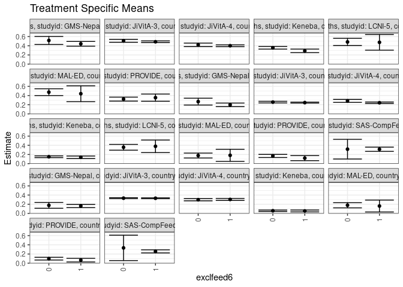

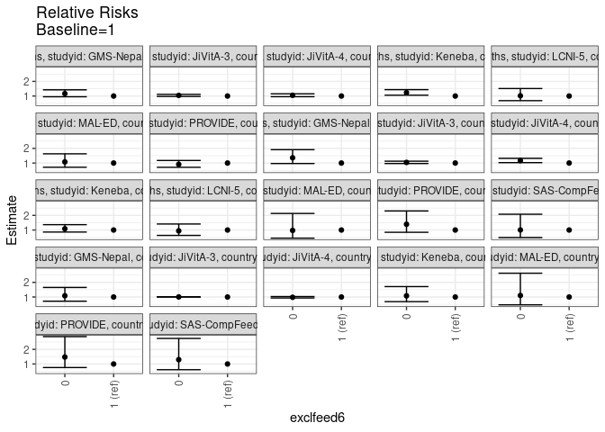

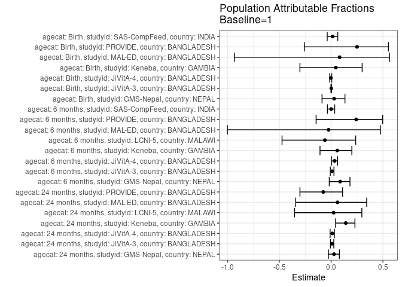

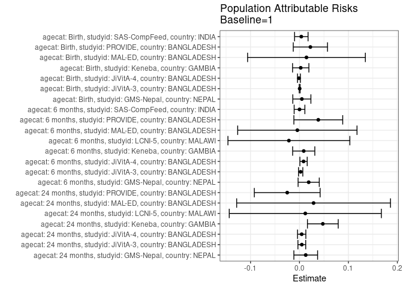

## Results Table

### Parameter: TSM

| agecat | studyid | country | intervention_level | baseline_level | estimate | ci_lower | ci_upper |
| --- | --- | --- | --- | --- | --- | --- | --- |
| Birth | GMS-Nepal | NEPAL | 1 | NA | 0.1620879 | 0.1267303 | 0.1974455 |
| Birth | GMS-Nepal | NEPAL | 0 | NA | 0.1760426 | 0.1128298 | 0.2392554 |
| Birth | JiVitA-3 | BANGLADESH | 1 | NA | 0.3306747 | 0.3214353 | 0.3399141 |
| Birth | JiVitA-3 | BANGLADESH | 0 | NA | 0.3326003 | 0.3228576 | 0.3423430 |
| Birth | JiVitA-4 | BANGLADESH | 1 | NA | 0.3046438 | 0.2831336 | 0.3261541 |
| Birth | JiVitA-4 | BANGLADESH | 0 | NA | 0.2985290 | 0.2746539 | 0.3224041 |
| Birth | Keneba | GAMBIA | 1 | NA | 0.0537581 | 0.0334503 | 0.0740658 |
| Birth | Keneba | GAMBIA | 0 | NA | 0.0580854 | 0.0428441 | 0.0733267 |
| Birth | MAL-ED | BANGLADESH | 1 | NA | 0.1612903 | 0.0315010 | 0.2910797 |
| Birth | MAL-ED | BANGLADESH | 0 | NA | 0.1781609 | 0.1211662 | 0.2351557 |
| Birth | PROVIDE | BANGLADESH | 1 | NA | 0.0667456 | 0.0271932 | 0.1062980 |
| Birth | PROVIDE | BANGLADESH | 0 | NA | 0.0985082 | 0.0685230 | 0.1284933 |
| Birth | SAS-CompFeed | INDIA | 1 | NA | 0.2572254 | 0.2236819 | 0.2907690 |
| Birth | SAS-CompFeed | INDIA | 0 | NA | 0.3333333 | 0.0564891 | 0.6101775 |
| 6 months | GMS-Nepal | NEPAL | 1 | NA | 0.1968923 | 0.1580923 | 0.2356922 |
| 6 months | GMS-Nepal | NEPAL | 0 | NA | 0.2675633 | 0.1930519 | 0.3420746 |
| 6 months | JiVitA-3 | BANGLADESH | 1 | NA | 0.2458596 | 0.2348995 | 0.2568197 |
| 6 months | JiVitA-3 | BANGLADESH | 0 | NA | 0.2563263 | 0.2384205 | 0.2742320 |
| 6 months | JiVitA-4 | BANGLADESH | 1 | NA | 0.2428377 | 0.2268521 | 0.2588234 |
| 6 months | JiVitA-4 | BANGLADESH | 0 | NA | 0.2829584 | 0.2505519 | 0.3153649 |
| 6 months | Keneba | GAMBIA | 1 | NA | 0.1391046 | 0.1117384 | 0.1664709 |
| 6 months | Keneba | GAMBIA | 0 | NA | 0.1509325 | 0.1318782 | 0.1699867 |
| 6 months | LCNI-5 | MALAWI | 1 | NA | 0.3782323 | 0.2414586 | 0.5150060 |
| 6 months | LCNI-5 | MALAWI | 0 | NA | 0.3565961 | 0.2938590 | 0.4193332 |
| 6 months | MAL-ED | BANGLADESH | 1 | NA | 0.1818182 | 0.0499388 | 0.3136975 |
| 6 months | MAL-ED | BANGLADESH | 0 | NA | 0.1767677 | 0.1235176 | 0.2300177 |
| 6 months | PROVIDE | BANGLADESH | 1 | NA | 0.1204744 | 0.0651403 | 0.1758085 |
| 6 months | PROVIDE | BANGLADESH | 0 | NA | 0.1679179 | 0.1338182 | 0.2020177 |
| 6 months | SAS-CompFeed | INDIA | 1 | NA | 0.3139842 | 0.2679102 | 0.3600581 |
| 6 months | SAS-CompFeed | INDIA | 0 | NA | 0.3157895 | 0.1014523 | 0.5301266 |
| 24 months | GMS-Nepal | NEPAL | 1 | NA | 0.4425419 | 0.3910047 | 0.4940790 |
| 24 months | GMS-Nepal | NEPAL | 0 | NA | 0.5154895 | 0.4278607 | 0.6031183 |
| 24 months | JiVitA-3 | BANGLADESH | 1 | NA | 0.4873502 | 0.4686891 | 0.5060113 |
| 24 months | JiVitA-3 | BANGLADESH | 0 | NA | 0.5082069 | 0.4763799 | 0.5400340 |
| 24 months | JiVitA-4 | BANGLADESH | 1 | NA | 0.4005783 | 0.3808834 | 0.4202731 |
| 24 months | JiVitA-4 | BANGLADESH | 0 | NA | 0.4207816 | 0.3836673 | 0.4578959 |
| 24 months | Keneba | GAMBIA | 1 | NA | 0.2893387 | 0.2509864 | 0.3276910 |
| 24 months | Keneba | GAMBIA | 0 | NA | 0.3566970 | 0.3274007 | 0.3859933 |
| 24 months | LCNI-5 | MALAWI | 1 | NA | 0.4748416 | 0.3039900 | 0.6456932 |
| 24 months | LCNI-5 | MALAWI | 0 | NA | 0.4834763 | 0.4044392 | 0.5625134 |
| 24 months | MAL-ED | BANGLADESH | 1 | NA | 0.4394672 | 0.2674468 | 0.6114875 |
| 24 months | MAL-ED | BANGLADESH | 0 | NA | 0.4730680 | 0.3992080 | 0.5469280 |
| 24 months | PROVIDE | BANGLADESH | 1 | NA | 0.3537360 | 0.2755244 | 0.4319475 |
| 24 months | PROVIDE | BANGLADESH | 0 | NA | 0.3222283 | 0.2789666 | 0.3654901 |

### Parameter: E(Y)

| agecat | studyid | country | intervention_level | baseline_level | estimate | ci_lower | ci_upper |
| --- | --- | --- | --- | --- | --- | --- | --- |
| Birth | GMS-Nepal | NEPAL | NA | NA | 0.1669627 | 0.1361293 | 0.1977961 |
| Birth | JiVitA-3 | BANGLADESH | NA | NA | 0.3310735 | 0.3218922 | 0.3402548 |
| Birth | JiVitA-4 | BANGLADESH | NA | NA | 0.3035714 | 0.2824097 | 0.3247332 |
| Birth | Keneba | GAMBIA | NA | NA | 0.0563079 | 0.0442416 | 0.0683742 |
| Birth | MAL-ED | BANGLADESH | NA | NA | 0.1756098 | 0.1233973 | 0.2278222 |
| Birth | PROVIDE | BANGLADESH | NA | NA | 0.0890538 | 0.0649864 | 0.1131212 |
| Birth | SAS-CompFeed | INDIA | NA | NA | 0.2609890 | 0.2179233 | 0.3040547 |
| 6 months | GMS-Nepal | NEPAL | NA | NA | 0.2157221 | 0.1812209 | 0.2502233 |
| 6 months | JiVitA-3 | BANGLADESH | NA | NA | 0.2482578 | 0.2382387 | 0.2582768 |
| 6 months | JiVitA-4 | BANGLADESH | NA | NA | 0.2511704 | 0.2362353 | 0.2661055 |
| 6 months | Keneba | GAMBIA | NA | NA | 0.1477987 | 0.1318701 | 0.1637274 |
| 6 months | LCNI-5 | MALAWI | NA | NA | 0.3566176 | 0.2995882 | 0.4136471 |
| 6 months | MAL-ED | BANGLADESH | NA | NA | 0.1774892 | 0.1281103 | 0.2268680 |
| 6 months | PROVIDE | BANGLADESH | NA | NA | 0.1589404 | 0.1297581 | 0.1881227 |
| 6 months | SAS-CompFeed | INDIA | NA | NA | 0.3140704 | 0.2712850 | 0.3568557 |
| 24 months | GMS-Nepal | NEPAL | NA | NA | 0.4553191 | 0.4102488 | 0.5003895 |
| 24 months | JiVitA-3 | BANGLADESH | NA | NA | 0.4921384 | 0.4750959 | 0.5091808 |
| 24 months | JiVitA-4 | BANGLADESH | NA | NA | 0.4050965 | 0.3867240 | 0.4234689 |
| 24 months | Keneba | GAMBIA | NA | NA | 0.3370787 | 0.3132517 | 0.3609056 |
| 24 months | LCNI-5 | MALAWI | NA | NA | 0.4867725 | 0.4153250 | 0.5582200 |
| 24 months | MAL-ED | BANGLADESH | NA | NA | 0.4682927 | 0.3998183 | 0.5367670 |
| 24 months | PROVIDE | BANGLADESH | NA | NA | 0.3287197 | 0.2903909 | 0.3670485 |

### Parameter: RR

| agecat | studyid | country | intervention_level | baseline_level | estimate | ci_lower | ci_upper |
| --- | --- | --- | --- | --- | --- | --- | --- |
| Birth | GMS-Nepal | NEPAL | 1 | 1 | 1.0000000 | 1.0000000 | 1.000000 |
| Birth | GMS-Nepal | NEPAL | 0 | 1 | 1.0860933 | 0.7137738 | 1.652623 |
| Birth | JiVitA-3 | BANGLADESH | 1 | 1 | 1.0000000 | 1.0000000 | 1.000000 |
| Birth | JiVitA-3 | BANGLADESH | 0 | 1 | 1.0058232 | 0.9930669 | 1.018743 |
| Birth | JiVitA-4 | BANGLADESH | 1 | 1 | 1.0000000 | 1.0000000 | 1.000000 |
| Birth | JiVitA-4 | BANGLADESH | 0 | 1 | 0.9799279 | 0.9320103 | 1.030309 |
| Birth | Keneba | GAMBIA | 1 | 1 | 1.0000000 | 1.0000000 | 1.000000 |
| Birth | Keneba | GAMBIA | 0 | 1 | 1.0804966 | 0.6822099 | 1.711310 |
| Birth | MAL-ED | BANGLADESH | 1 | 1 | 1.0000000 | 1.0000000 | 1.000000 |
| Birth | MAL-ED | BANGLADESH | 0 | 1 | 1.1045977 | 0.4646502 | 2.625924 |
| Birth | PROVIDE | BANGLADESH | 1 | 1 | 1.0000000 | 1.0000000 | 1.000000 |
| Birth | PROVIDE | BANGLADESH | 0 | 1 | 1.4758746 | 0.7587484 | 2.870788 |
| Birth | SAS-CompFeed | INDIA | 1 | 1 | 1.0000000 | 1.0000000 | 1.000000 |
| Birth | SAS-CompFeed | INDIA | 0 | 1 | 1.2958801 | 0.6113712 | 2.746785 |
| 6 months | GMS-Nepal | NEPAL | 1 | 1 | 1.0000000 | 1.0000000 | 1.000000 |
| 6 months | GMS-Nepal | NEPAL | 0 | 1 | 1.3589323 | 0.9657629 | 1.912164 |
| 6 months | JiVitA-3 | BANGLADESH | 1 | 1 | 1.0000000 | 1.0000000 | 1.000000 |
| 6 months | JiVitA-3 | BANGLADESH | 0 | 1 | 1.0425719 | 0.9663180 | 1.124843 |
| 6 months | JiVitA-4 | BANGLADESH | 1 | 1 | 1.0000000 | 1.0000000 | 1.000000 |
| 6 months | JiVitA-4 | BANGLADESH | 0 | 1 | 1.1652159 | 1.0280242 | 1.320716 |
| 6 months | Keneba | GAMBIA | 1 | 1 | 1.0000000 | 1.0000000 | 1.000000 |
| 6 months | Keneba | GAMBIA | 0 | 1 | 1.0850281 | 0.8619036 | 1.365914 |
| 6 months | LCNI-5 | MALAWI | 1 | 1 | 1.0000000 | 1.0000000 | 1.000000 |
| 6 months | LCNI-5 | MALAWI | 0 | 1 | 0.9427966 | 0.6303840 | 1.410038 |
| 6 months | MAL-ED | BANGLADESH | 1 | 1 | 1.0000000 | 1.0000000 | 1.000000 |
| 6 months | MAL-ED | BANGLADESH | 0 | 1 | 0.9722222 | 0.4432703 | 2.132369 |
| 6 months | PROVIDE | BANGLADESH | 1 | 1 | 1.0000000 | 1.0000000 | 1.000000 |
| 6 months | PROVIDE | BANGLADESH | 0 | 1 | 1.3938059 | 0.8439511 | 2.301904 |
| 6 months | SAS-CompFeed | INDIA | 1 | 1 | 1.0000000 | 1.0000000 | 1.000000 |
| 6 months | SAS-CompFeed | INDIA | 0 | 1 | 1.0057497 | 0.4866253 | 2.078668 |
| 24 months | GMS-Nepal | NEPAL | 1 | 1 | 1.0000000 | 1.0000000 | 1.000000 |
| 24 months | GMS-Nepal | NEPAL | 0 | 1 | 1.1648378 | 0.9519903 | 1.425274 |
| 24 months | JiVitA-3 | BANGLADESH | 1 | 1 | 1.0000000 | 1.0000000 | 1.000000 |
| 24 months | JiVitA-3 | BANGLADESH | 0 | 1 | 1.0427962 | 0.9736568 | 1.116845 |
| 24 months | JiVitA-4 | BANGLADESH | 1 | 1 | 1.0000000 | 1.0000000 | 1.000000 |
| 24 months | JiVitA-4 | BANGLADESH | 0 | 1 | 1.0504354 | 0.9565466 | 1.153540 |
| 24 months | Keneba | GAMBIA | 1 | 1 | 1.0000000 | 1.0000000 | 1.000000 |
| 24 months | Keneba | GAMBIA | 0 | 1 | 1.2328009 | 1.0573662 | 1.437343 |
| 24 months | LCNI-5 | MALAWI | 1 | 1 | 1.0000000 | 1.0000000 | 1.000000 |
| 24 months | LCNI-5 | MALAWI | 0 | 1 | 1.0181844 | 0.6852193 | 1.512946 |
| 24 months | MAL-ED | BANGLADESH | 1 | 1 | 1.0000000 | 1.0000000 | 1.000000 |
| 24 months | MAL-ED | BANGLADESH | 0 | 1 | 1.0764580 | 0.7106037 | 1.630672 |
| 24 months | PROVIDE | BANGLADESH | 1 | 1 | 1.0000000 | 1.0000000 | 1.000000 |
| 24 months | PROVIDE | BANGLADESH | 0 | 1 | 0.9109289 | 0.7067483 | 1.174098 |

### Parameter: PAR

| agecat | studyid | country | intervention_level | baseline_level | estimate | ci_lower | ci_upper |
| --- | --- | --- | --- | --- | --- | --- | --- |
| Birth | GMS-Nepal | NEPAL | 1 | NA | 0.0048748 | -0.0135979 | 0.0233474 |
| Birth | JiVitA-3 | BANGLADESH | 1 | NA | 0.0003988 | -0.0005364 | 0.0013340 |
| Birth | JiVitA-4 | BANGLADESH | 1 | NA | -0.0010724 | -0.0040204 | 0.0018756 |
| Birth | Keneba | GAMBIA | 1 | NA | 0.0025498 | -0.0141204 | 0.0192201 |
| Birth | MAL-ED | BANGLADESH | 1 | NA | 0.0143194 | -0.1059999 | 0.1346388 |
| Birth | PROVIDE | BANGLADESH | 1 | NA | 0.0223082 | -0.0126823 | 0.0572987 |
| Birth | SAS-CompFeed | INDIA | 1 | NA | 0.0037636 | -0.0100156 | 0.0175428 |
| 6 months | GMS-Nepal | NEPAL | 1 | NA | 0.0188299 | -0.0028003 | 0.0404600 |
| 6 months | JiVitA-3 | BANGLADESH | 1 | NA | 0.0023982 | -0.0020241 | 0.0068205 |
| 6 months | JiVitA-4 | BANGLADESH | 1 | NA | 0.0083327 | 0.0008598 | 0.0158055 |
| 6 months | Keneba | GAMBIA | 1 | NA | 0.0086941 | -0.0139539 | 0.0313421 |
| 6 months | LCNI-5 | MALAWI | 1 | NA | -0.0216146 | -0.1461651 | 0.1029359 |
| 6 months | MAL-ED | BANGLADESH | 1 | NA | -0.0043290 | -0.1262357 | 0.1175777 |
| 6 months | PROVIDE | BANGLADESH | 1 | NA | 0.0384660 | -0.0114358 | 0.0883678 |
| 6 months | SAS-CompFeed | INDIA | 1 | NA | 0.0000862 | -0.0108674 | 0.0110398 |
| 24 months | GMS-Nepal | NEPAL | 1 | NA | 0.0127773 | -0.0114664 | 0.0370209 |
| 24 months | JiVitA-3 | BANGLADESH | 1 | NA | 0.0047881 | -0.0031656 | 0.0127419 |
| 24 months | JiVitA-4 | BANGLADESH | 1 | NA | 0.0045182 | -0.0039595 | 0.0129959 |
| 24 months | Keneba | GAMBIA | 1 | NA | 0.0477400 | 0.0162826 | 0.0791974 |
| 24 months | LCNI-5 | MALAWI | 1 | NA | 0.0119309 | -0.1434771 | 0.1673388 |
| 24 months | MAL-ED | BANGLADESH | 1 | NA | 0.0288255 | -0.1283359 | 0.1859869 |
| 24 months | PROVIDE | BANGLADESH | 1 | NA | -0.0250163 | -0.0922550 | 0.0422225 |

### Parameter: PAF

| agecat | studyid | country | intervention_level | baseline_level | estimate | ci_lower | ci_upper |
| --- | --- | --- | --- | --- | --- | --- | --- |
| Birth | GMS-Nepal | NEPAL | 1 | NA | 0.0291968 | -0.0879191 | 0.1337051 |
| Birth | JiVitA-3 | BANGLADESH | 1 | NA | 0.0012046 | -0.0016248 | 0.0040260 |
| Birth | JiVitA-4 | BANGLADESH | 1 | NA | -0.0035326 | -0.0132816 | 0.0061225 |
| Birth | Keneba | GAMBIA | 1 | NA | 0.0452840 | -0.3016627 | 0.2997552 |
| Birth | MAL-ED | BANGLADESH | 1 | NA | 0.0815412 | -0.9360258 | 0.5642793 |
| Birth | PROVIDE | BANGLADESH | 1 | NA | 0.2505024 | -0.2596251 | 0.5540366 |
| Birth | SAS-CompFeed | INDIA | 1 | NA | 0.0144204 | -0.0378960 | 0.0640998 |
| 6 months | GMS-Nepal | NEPAL | 1 | NA | 0.0872876 | -0.0181850 | 0.1818344 |
| 6 months | JiVitA-3 | BANGLADESH | 1 | NA | 0.0096600 | -0.0083197 | 0.0273191 |
| 6 months | JiVitA-4 | BANGLADESH | 1 | NA | 0.0331754 | 0.0031065 | 0.0623373 |
| 6 months | Keneba | GAMBIA | 1 | NA | 0.0588239 | -0.1075621 | 0.2002141 |
| 6 months | LCNI-5 | MALAWI | 1 | NA | -0.0606101 | -0.4744792 | 0.2370908 |
| 6 months | MAL-ED | BANGLADESH | 1 | NA | -0.0243902 | -1.0028399 | 0.4760563 |
| 6 months | PROVIDE | BANGLADESH | 1 | NA | 0.2420152 | -0.1452580 | 0.4983305 |
| 6 months | SAS-CompFeed | INDIA | 1 | NA | 0.0002744 | -0.0352245 | 0.0345560 |
| 24 months | GMS-Nepal | NEPAL | 1 | NA | 0.0280623 | -0.0267946 | 0.0799884 |
| 24 months | JiVitA-3 | BANGLADESH | 1 | NA | 0.0097293 | -0.0065617 | 0.0257566 |
| 24 months | JiVitA-4 | BANGLADESH | 1 | NA | 0.0111534 | -0.0099678 | 0.0318328 |
| 24 months | Keneba | GAMBIA | 1 | NA | 0.1416286 | 0.0430875 | 0.2300221 |
| 24 months | LCNI-5 | MALAWI | 1 | NA | 0.0245102 | -0.3532080 | 0.2967966 |
| 24 months | MAL-ED | BANGLADESH | 1 | NA | 0.0615545 | -0.3421951 | 0.3438509 |
| 24 months | PROVIDE | BANGLADESH | 1 | NA | -0.0761021 | -0.3013510 | 0.1101588 |